# Lecture Notes (JSV) - Multivariate analysis - 30-01-2023 Exercise

#### Context

Field trial in rural northern Ghana on the effect of Vitamin A given in large doses to children under 5 . The data in this exercise were taken from the baseline survey. They include interview data provided by the mother or her substitute, clinical and laboratory data. You will find the da-ta in VASTCHS.csv . Please note that in this csv file semi colons (;) have been used as field separators and comma’s as decimal-point characters. Take this into account when you import the dataset in R!

### 1. Preparation

##### Keyboard shortcuts:

```
- `ctrl + shift + m` -\> `%>%` (operador pipe)
- `ctrl + alt + i` -\> Crea un chunk de código
```

##### Set working directory

```
- setwd("C:/Users/xxx/yyy")
- getwd()
```

##### Load (basic) packages

To import Excel files library(readxl) To calculate OR or RR library(EpiStats)

```r
library(readxl)                      # To import Excel files
library(tidyverse)                   # Varias funciones de tidyverse (dplyr, ggplot2, etc.)
library(dslabs)                      # Paquete que contiene la base de datos de Gapminder
library(EpiStats)                    # To calculate OR or RR
```

##### Import data

- From Text (.csv)-example
  - data <- read.csv(“H:/Teaching/My_Courses/IIH-epistat/R/Sharm_Exercise/mysharm.csv”)
- From Excel file (.xls, .xlsx)-example
  - library(readxl)
  - data <- read_excel(“H:/Teaching/My_Courses/IIH-epistat/R/Sharm_Exercise/mysharm.xlsx”)
- from STATA file (.dta)-example
  - library(haven)
  - data <- read_dta(“H:/Teaching/My_Courses/IIH-epistat/R/Sharm_Exercise/mysharm.dta”)

Importing a CSV under the name of vastchs, with “;” as separator, and with “,” as decimal:

```r
vastchs <- read.csv("C:/Users/pined/OneDrive - Universidad Nacional Mayor de San Marcos/Javier 2022/Belgica/AC2/Linear Regresion Exercise Database/Datasets/VASTCHS.csv", sep=";", dec= ",")
```

## 2. Descriptive Statistics

#### Summary

##### Numeric Variable

```r
summary(vastchs$AGE)                      #summary
```

```
   Min. 1st Qu.  Median    Mean 3rd Qu.    Max.
   0.00   10.00   21.00   22.49   34.00   55.00
```

```r
var(vastchs$AGE)                          #variance
```

```
[1] 200.287
```

```r
sd(vastchs$AGE)                           #standart desviation
```

```
[1] 14.15228
```

##### Categoric Variable

Frecuency and Percentage

```r
table(vastchs$SEX)                        #Counting
```

```
  1   2
560 577
```

```r
prop.table(table(vastchs$SEX))            #Percentages
```

```
        1         2
0.4925242 0.5074758
```

Recode to a factor - From number to string

```r
vastchs$SEX2<-factor(vastchs$SEX, levels=c(1,2))
summary(vastchs$SEX2)
```

```
  1   2
560 577
```

#### Creating variables- Recoding: Yes/No = 1/0

```r
vastchs$wasted<- ifelse(vastchs$WHZ< -2, 1,0)     #wasted si es menos a -2 poner 1 sino 0
vastchs$stunded<- ifelse(vastchs$HAZ< -2, 1,0)     #stunded si es menos a -2 poner 1 sino 0
vastchs$underweight<- ifelse(vastchs$WAZ< -2, 1,0)     #undweig si es menos a -2 poner 1 sino 0
vastchs$anemia<- ifelse(vastchs$HB< 8, 1,0)     #anemia si es menos que 8 poner 1 sino 0
vastchs$vitadef<- ifelse(vastchs$RETINOL< 0.7, 1,0)     #Def of VitA si es menos de 0.7 poner 1 sino 0

vastchs$HANDPUMP2<- ifelse(vastchs$HANDPUMP== 1, 1,0)
```

```r
table(vastchs$vitadef)                        #Counting
```

```
  0   1
302 835
```

```r
prop.table(table(vastchs$vitadef))            #Percentages
```

```
        0         1
0.2656113 0.7343887
```

```r
table(vastchs$HANDPUMP, vastchs$HANDPUMP2)
```

```
      0   1
  1   0 903
  2  65   0
  3 169   0
```

#### Breast feeding as a potential protective factor agains vit A deficiency

```r
table (vastchs$CURRBF)            #To see what values have CURRBF
```

```
  1   2
793 344
```

```r
vastchs$CURRBF2<- ifelse(vastchs$CURRBF==1, 1,0)    #To change values to 0 to 1
table (vastchs$CURRBF, vastchs$CURRBF2)     #To see if has already changed
```

```
      0   1
  1   0 793
  2 344   0
```

Calculate de OR

```r
table (vastchs$vitadef, vastchs$CURRBF2)
```

```
      0   1
  0  74 228
  1 270 565
```

```r
prop.table(table(vastchs$vitadef, vastchs$CURRBF2))       #Proportion above total sum
```

```
             0          1
  0 0.06508355 0.20052770
  1 0.23746702 0.49692172
```

```r
prop.table(table(vastchs$vitadef, vastchs$CURRBF2), margin = 1) #Proportion above ROW
```

```
            0         1
  0 0.2450331 0.7549669
  1 0.3233533 0.6766467
```

```r
cc(vastchs,vitadef,CURRBF2)
```

```
$df1
                   Cases Controls Total
Exposed              565      228   793
Unexposed            270       74   344
Total                835      302  1137
Proportion exposed  0.68     0.75  0.70

$df2
                Point estimate 95%CI-ll 95%CI-ul
Odds ratio                0.68     0.50     0.92
Prev. frac. ex.           0.32     0.08     0.50
Prev. frac. pop           0.24       NA       NA
chi2(1)                   6.45       NA       NA
Pr>chi2                  0.011       NA       NA
```

Agruping Variable

```r
# Regrouping (e.g. age in months to agegroup)
          vastchs$agegrp <- NA
          vastchs$agegrp[vastchs$AGE<12] <- "1"
          vastchs$agegrp[vastchs$AGE>11 & vastchs$AGE<24] <- "2"
          vastchs$agegrp[vastchs$AGE>23 & vastchs$AGE<36] <- "3"
          vastchs$agegrp[vastchs$AGE>35 & vastchs$AGE<48] <- "4"
          vastchs$agegrp[vastchs$AGE>47 & vastchs$AGE<60] <- "5"
          # don't forget to convert agegrp to a factor variable
          vastchs$agegrp <- factor(vastchs$agegrp)
```

Being under2 is a coufunder?

```r
vastchs$under2 <- "0"
vastchs$under2[vastchs$AGE<2] <- "1"
vastchs$agegrp <- factor(vastchs$agegrp)
```

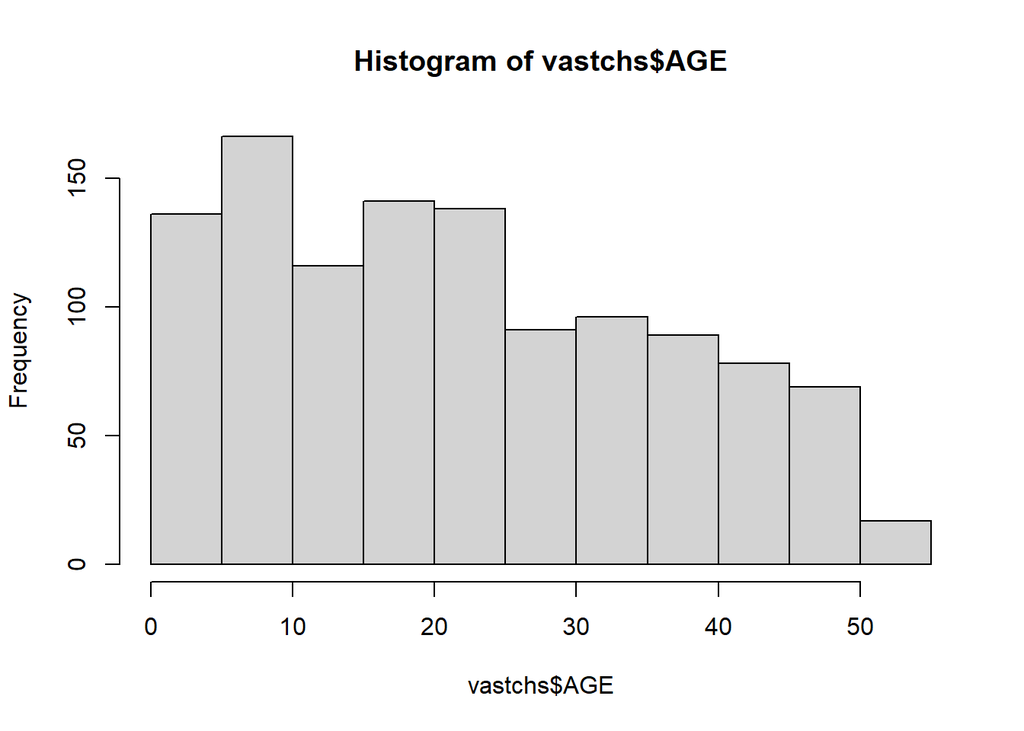

```r
hist(vastchs$AGE)
```

```r
summary(vastchs$AGE)
```

```
   Min. 1st Qu.  Median    Mean 3rd Qu.    Max.
   0.00   10.00   21.00   22.49   34.00   55.00
```

With more options

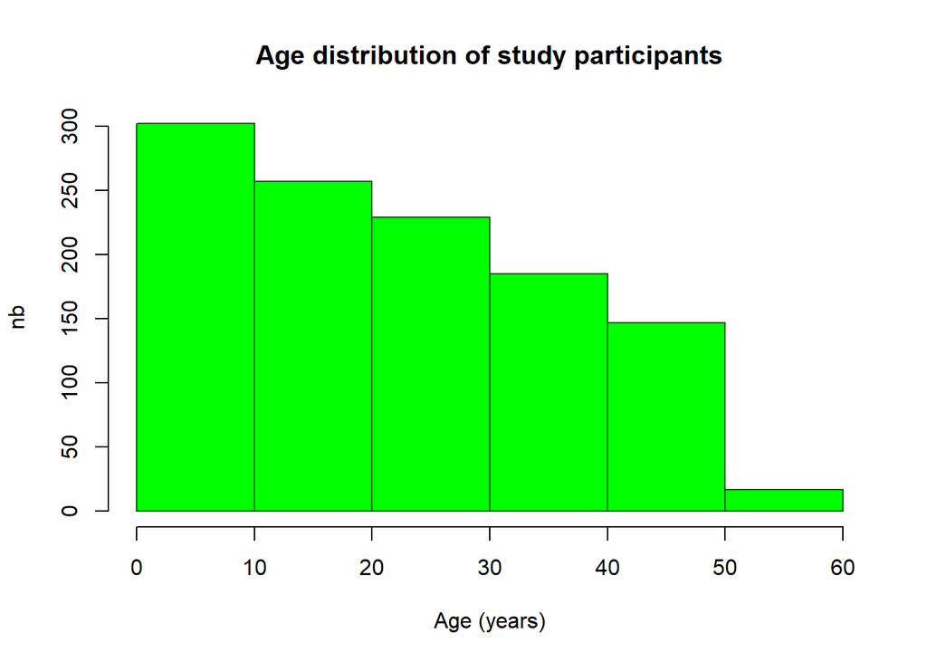

```r
hist(vastchs$AGE,main="Age distribution of study participants",
     xlab="Age (years)", ylab="nb", col="green", border="dark green",
     breaks=5)
```

With Tidyverse

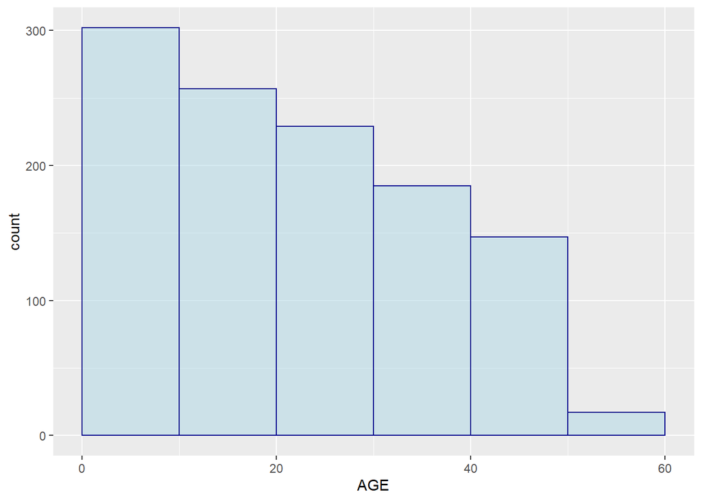

```r
ggplot(vastchs, aes(x=AGE)) +
  geom_histogram( color="darkblue", fill="lightblue",  alpha=0.5, origin = 0, binwidth=10)
```

### Summary of a categorical variable